First, let us load the data and necessary packages:

```r
load("ames_train.Rdata")
library(MASS)
library(dplyr)
library(ggplot2)
```

# 1

Make a labeled histogram (with 30 bins) of the ages of the houses in the data set, and describe the distribution.

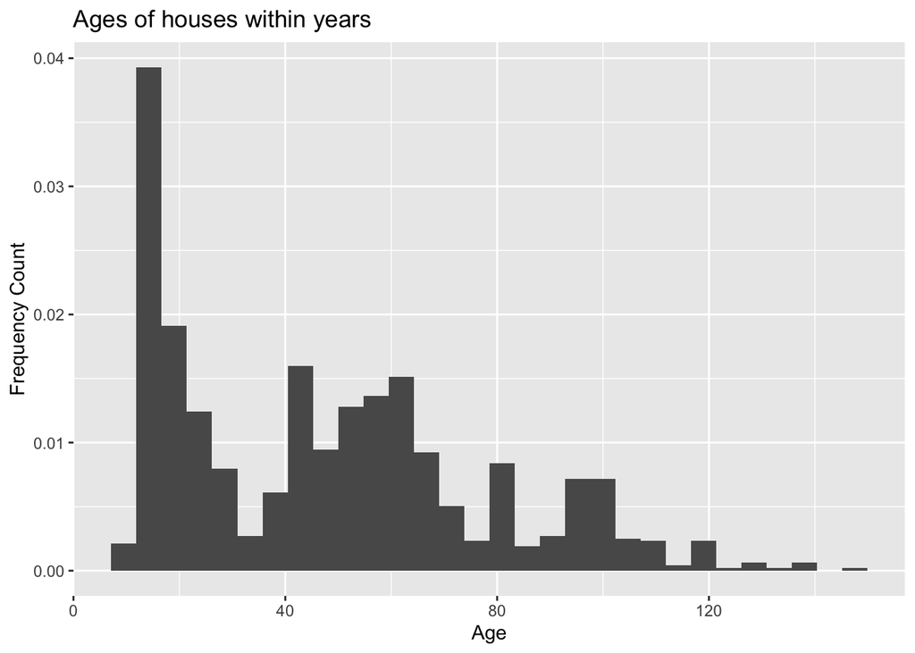

```r
ames_train$Age <-
  sapply(ames_train$Year.Built, function(x) 2020 - x)

ggplot(data = ames_train, aes(x = Age, y = ..density..)) +
  geom_histogram(bins = 30) +
  labs(title = "Ages of houses within years", x = 'Age', y = "Frequency Count")
```

The histogram above shows the distribution is right-skewed with multimodality. And there’s no data at age 0 since no house age can be less than 0 year. Meanwhile, with the increase of houses’ age, more of them would be replaced or redecorated with new ones, resulting less old houses in this dataset.

# 2

The mantra in real estate is “Location, Location, Location!” Make a graphical display that relates a home price to its neighborhood in Ames, Iowa. Which summary statistics are most appropriate to use for determining the most expensive, least expensive, and most heterogeneous (having the most variation in housing price) neighborhoods? Report which neighborhoods these are based on the summary statistics of your choice. Report the value of your chosen summary statistics for these neighborhoods.

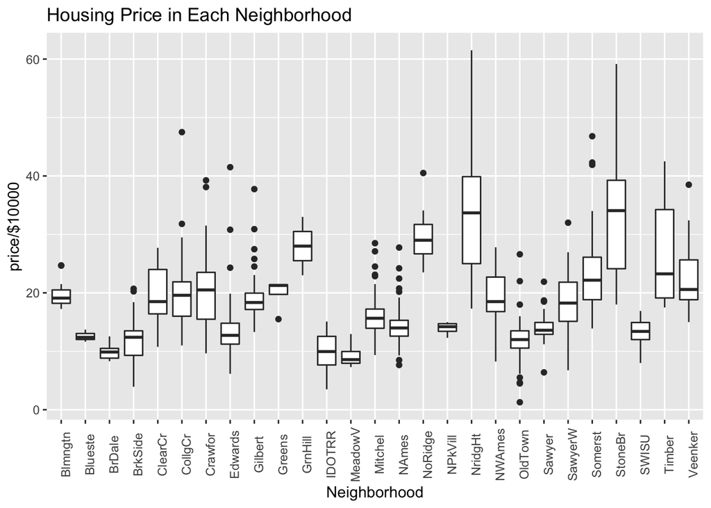

```r
ggplot(ames_train,aes(x = Neighborhood, y = price/10000)) +
  geom_boxplot() +
  labs(title = "Housing Price in Each Neighborhood", x = "Neighborhood", y = "price/$10000") +
  theme(axis.text.x = element_text(angle = 90))
```

Standard deviation would be a helpful statistic to determine the spread variation of houses price among neighborhoods. To identify the most and least expensive neighborhood, we would take median as a good factor to measure.

```r
ames_train %>%
  group_by(Neighborhood) %>%
  summarise(sd = sd(price, na.rm = TRUE), median = median(price, na.rm = TRUE)) %>%
  arrange(desc(median))
```

```
## # A tibble: 27 x 3
##    Neighborhood      sd  median
##    <fct>          <dbl>   <dbl>
##  1 StoneBr      123459. 340692.
##  2 NridgHt      105089. 336860
##  3 NoRidge       35889. 290000
##  4 GrnHill       70711. 280000
##  5 Timber        84030. 232500
##  6 Somerst       65199. 221650
##  7 Greens        29063. 212625
##  8 Veenker       72545. 205750
##  9 Crawfor       71268. 205000
## 10 CollgCr       52786. 195800
## # … with 17 more rows
```

The most expensive neighborhood is StoneBr, with median price $340691.5

The least expensive neighborhood is Meadow V, with median cost $85750

The most heterogeneous neighborhood is StoneBr, with standard deviation 123459.10

# 3

Which variable has the largest number of missing values? Explain why it makes sense that there are so many missing values for this variable.

```r
# type your code for Question 3 here, and Knit
colSums(is.na(ames_train))
```

```
##             PID            area           price     MS.SubClass       MS.Zoning
##               0               0               0               0               0
##    Lot.Frontage        Lot.Area          Street           Alley       Lot.Shape
##             167               0               0             933               0
##    Land.Contour       Utilities      Lot.Config      Land.Slope    Neighborhood
##               0               0               0               0               0
##     Condition.1     Condition.2       Bldg.Type     House.Style    Overall.Qual
##               0               0               0               0               0
##    Overall.Cond      Year.Built  Year.Remod.Add      Roof.Style       Roof.Matl
##               0               0               0               0               0
##    Exterior.1st    Exterior.2nd    Mas.Vnr.Type    Mas.Vnr.Area      Exter.Qual
##               0               0               0               7               0
##      Exter.Cond      Foundation       Bsmt.Qual       Bsmt.Cond   Bsmt.Exposure
##               0               0              21              21              21
##  BsmtFin.Type.1    BsmtFin.SF.1  BsmtFin.Type.2    BsmtFin.SF.2     Bsmt.Unf.SF
##              21               1              21               1               1
##   Total.Bsmt.SF         Heating      Heating.QC     Central.Air      Electrical
##               1               0               0               0               0
##     X1st.Flr.SF     X2nd.Flr.SF Low.Qual.Fin.SF  Bsmt.Full.Bath  Bsmt.Half.Bath
##               0               0               0               1               1
##       Full.Bath       Half.Bath   Bedroom.AbvGr   Kitchen.AbvGr    Kitchen.Qual
##               0               0               0               0               0
##   TotRms.AbvGrd      Functional      Fireplaces    Fireplace.Qu     Garage.Type
##               0               0               0             491              46
##   Garage.Yr.Blt   Garage.Finish     Garage.Cars     Garage.Area     Garage.Qual
##              48              46               1               1              47
##     Garage.Cond     Paved.Drive    Wood.Deck.SF   Open.Porch.SF  Enclosed.Porch
##              47               0               0               0               0
##     X3Ssn.Porch    Screen.Porch       Pool.Area         Pool.QC           Fence
##               0               0               0             997             798
##    Misc.Feature        Misc.Val         Mo.Sold         Yr.Sold       Sale.Type
##             971               0               0               0               0
##  Sale.Condition             Age
##               0               0
```

According to the result, “Pool.QC” has the largest number of missing values, which is 997. Pool.QC is a variable demonstrating swimming pool quality.According to 0 swimming pool in Pool.Area field, it makes sense that this area has so many missing values for the Pool.QC variable.

# 4

We want to predict the natural log of the home prices. Candidate explanatory variables are lot size in square feet (Lot.Area), slope of property (Land.Slope), original construction date (Year.Built), remodel date (Year.Remod.Add), and the number of bedrooms above grade (Bedroom.AbvGr). Pick a model selection or model averaging method covered in the Specialization, and describe how this method works. Then, use this method to find the best multiple regression model for predicting the natural log of the home prices.

```r
# We set up a new dataset with explanatory variables and respondent variable "price"
new1 <- ames_train %>%
  select(price, Lot.Area, Land.Slope, Year.Built, Year.Remod.Add, Bedroom.AbvGr)

summary(new1)
```

```
##      price           Lot.Area      Land.Slope   Year.Built   Year.Remod.Add
##  Min.   : 12789   Min.   :  1470   Gtl:962    Min.   :1872   Min.   :1950
##  1st Qu.:129762   1st Qu.:  7314   Mod: 33    1st Qu.:1955   1st Qu.:1966
##  Median :159467   Median :  9317   Sev:  5    Median :1975   Median :1992
##  Mean   :181190   Mean   : 10352              Mean   :1972   Mean   :1984
##  3rd Qu.:213000   3rd Qu.: 11650              3rd Qu.:2001   3rd Qu.:2004
##  Max.   :615000   Max.   :215245              Max.   :2010   Max.   :2010
##  Bedroom.AbvGr
##  Min.   :0.000
##  1st Qu.:2.000
##  Median :3.000
##  Mean   :2.806
##  3rd Qu.:3.000
##  Max.   :6.000
```

```r
#Set up our initial model
#log(price) ~ Lot.Area + Land.Slope + Year.Built + Year.Remod.Add + Bedroom.AbvGr

initial_model <- lm(log(price) ~., data = new1)

summary(initial_model)
```

```
##
## Call:
## lm(formula = log(price) ~ ., data = new1)
##
## Residuals:
##     Min      1Q  Median      3Q     Max
## -2.0878 -0.1651 -0.0211  0.1657  0.9945
##
## Coefficients:
##                  Estimate Std. Error t value Pr(>|t|)
## (Intercept)    -1.371e+01  8.574e-01 -15.996  < 2e-16 ***
## Lot.Area        1.028e-05  1.106e-06   9.296  < 2e-16 ***
## Land.SlopeMod   1.384e-01  4.991e-02   2.773  0.00565 **
## Land.SlopeSev  -4.567e-01  1.514e-01  -3.016  0.00263 **
## Year.Built      6.049e-03  3.788e-04  15.968  < 2e-16 ***
## Year.Remod.Add  6.778e-03  5.468e-04  12.395  < 2e-16 ***
## Bedroom.AbvGr   8.686e-02  1.077e-02   8.063 2.12e-15 ***
## ---
## Signif. codes:  0 '***' 0.001 '**' 0.01 '*' 0.05 '.' 0.1 ' ' 1
##
## Residual standard error: 0.279 on 993 degrees of freedom
## Multiple R-squared:  0.5625, Adjusted R-squared:  0.5598
## F-statistic: 212.8 on 6 and 993 DF,  p-value: < 2.2e-16
```

Now let’s use the Backward Elimination method with main fous on adjusted R-squared value.

From the summary of our initial model, we got R-squared value of 0.5625 and Adjusted R-squared at 0.5598. Since p-value here is below 0.05, all our selected explanatory variables are valid for this model. Next, we would check whether removing any of these explanatory variables would give rise to a higher Adjusted R-squared.

```r
#Remove Lot.Area
model_noLA <- lm(log(price) ~ Land.Slope + Year.Built + Year.Remod.Add + Bedroom.AbvGr, data=ames_train)

#Remove Land.Slope
model_noLS <- lm(log(price) ~ Lot.Area +Year.Built + Year.Remod.Add + Bedroom.AbvGr, data = ames_train)

#Remove Year.Built
model_noYB <- lm(log(price) ~ Lot.Area + Land.Slope + Year.Remod.Add + Bedroom.AbvGr, data = ames_train)

#Remove Year.Remod.Add
model_noYRA <- lm(log(price) ~ Lot.Area + Land.Slope + Year.Built + Bedroom.AbvGr, data = ames_train)

#Remove Bedroom.AbvGr
model_noBA <- lm(log(price) ~ Lot.Area + Land.Slope + Year.Built + Year.Remod.Add, data = ames_train)


#Establish new dataset for each Adjusted R-squared for our new selected models

m1 <- summary(model_noLA)$adj.r.squared
m2 <- summary(model_noLS)$adj.r.squared
m3 <- summary(model_noYB)$adj.r.squared
m4 <- summary(model_noYRA)$adj.r.squared
m5 <- summary(model_noBA)$adj.r.squared

R_Squared <- rbind(m1,m2,m3,m4,m5)
removed_models <- c("Lot.Area Removed", "Land.Slope.Removed", "Year.Built Removed", "Year.Remod.Add Removed",
           "Bedroom.AbvGr Removed")
df <- data.frame(cbind(removed_models, R_Squared))

#Add column names for this new data frame
colnames(df) <- c("Models Removed", "Adjusted R_Squared")

df
```

```
##            Models Removed Adjusted R_Squared
## m1       Lot.Area Removed  0.522009031037836
## m2     Land.Slope.Removed  0.552606180049213
## m3     Year.Built Removed  0.447366335111107
## m4 Year.Remod.Add Removed  0.492238381396363
## m5  Bedroom.AbvGr Removed  0.531485946233459
```

Compared with initial Adjusted R-Squared of 0.5598, it’s obvious that none of these explanatory variables increased when any of them were removed. Therefore, we should apply all of them for our final model.

# 5

Which home has the largest squared residual in the previous analysis (Question 4)? Looking at all the variables in the data set, can you explain why this home stands out from the rest (what factors contribute to the high squared residual and why are those factors relevant)?

```r
summary(new1)
```

```
##      price           Lot.Area      Land.Slope   Year.Built   Year.Remod.Add
##  Min.   : 12789   Min.   :  1470   Gtl:962    Min.   :1872   Min.   :1950
##  1st Qu.:129762   1st Qu.:  7314   Mod: 33    1st Qu.:1955   1st Qu.:1966
##  Median :159467   Median :  9317   Sev:  5    Median :1975   Median :1992
##  Mean   :181190   Mean   : 10352              Mean   :1972   Mean   :1984
##  3rd Qu.:213000   3rd Qu.: 11650              3rd Qu.:2001   3rd Qu.:2004
##  Max.   :615000   Max.   :215245              Max.   :2010   Max.   :2010
##  Bedroom.AbvGr
##  Min.   :0.000
##  1st Qu.:2.000
##  Median :3.000
##  Mean   :2.806
##  3rd Qu.:3.000
##  Max.   :6.000
```

```r
largest_residuals <- which(abs(resid(initial_model))== max(abs(resid(initial_model))))

largest_residuals
```

```
## 428
## 428
```

The house 428 is with the highest residuals in this dataset. And one apparent feature of this home is its price at $12,789, which is clearly far below the price of other houses given the lot size and the number of bedrooms.

# 6

Use the same model selection method you chose in Question 4 to again find the best multiple regression model to predict the natural log of home prices, but this time **replacing Lot.Area with log(Lot.Area)**. Do you arrive at a model including the same set of predictors?

```r
#Removed Lot.Area
logmodel_noLA <- lm(log(price) ~ Land.Slope + Year.Built +
                      Year.Remod.Add + Bedroom.AbvGr,
                    data = ames_train)

#Removed Land.Slope
logmodel_noLS <- lm(log(price) ~ log(Lot.Area) + Year.Built + Year.Remod.Add + Bedroom.AbvGr,
                    data = ames_train)

#Removed Year.Built
logmodel_noYB <- lm(log(price) ~ log(Lot.Area) + Land.Slope + Year.Remod.Add + Bedroom.AbvGr,
                    data = ames_train)

#Removed Year.Remod.Add
logmodel_noYRA <- lm(log(price) ~ log(Lot.Area) + Land.Slope + Year.Built + Bedroom.AbvGr,
                     data = ames_train)

#Removed Bedroom.AbvGr
logmodel_noBA <- lm(log(price) ~ log(Lot.Area) + Land.Slope + Year.Built + Year.Remod.Add,
                    data = ames_train)

#Establish new dataset for each Adjusted R-squared for our new selected models
m21 <- summary(logmodel_noLA)$adj.r.squared
m22 <- summary(logmodel_noLS)$adj.r.squared
m23 <- summary(logmodel_noYB)$adj.r.squared
m24 <- summary(logmodel_noYRA)$adj.r.squared
m25 <- summary(logmodel_noBA)$adj.r.squared

R_Squared2 <- rbind(m21, m22, m23, m24, m25)
model2 <- c("Removed Lot.Area", "Removed Land.Slope", "Removed Year.Built", "Removed Remod.Add",
            "Removed BedroomAbvGr")

df <- data.frame(cbind(model2, R_Squared2))

colnames(df) <- c("Model", "Adjusted R_Squared")

df
```

```
##                    Model Adjusted R_Squared
## m21     Removed Lot.Area  0.522009031037836
## m22   Removed Land.Slope  0.601483060025884
## m23   Removed Year.Built  0.493228218512004
## m24    Removed Remod.Add  0.536392090226433
## m25 Removed BedroomAbvGr  0.591088776010984
```

```r
#Recall model with log(Lot.Area)
logmodel <- lm(log(price) ~ log(Lot.Area) + Land.Slope + Year.Built +Year.Remod.Add + Bedroom.AbvGr,
         data = ames_train)
summary(logmodel)
```

```
##
## Call:
## lm(formula = log(price) ~ log(Lot.Area) + Land.Slope + Year.Built +
##     Year.Remod.Add + Bedroom.AbvGr, data = ames_train)
##
## Residuals:
##      Min       1Q   Median       3Q      Max
## -2.14050 -0.15650 -0.01561  0.15350  0.90854
##
## Coefficients:
##                  Estimate Std. Error t value Pr(>|t|)
## (Intercept)    -1.553e+01  8.197e-01 -18.947  < 2e-16 ***
## log(Lot.Area)   2.442e-01  1.708e-02  14.297  < 2e-16 ***
## Land.SlopeMod   1.151e-01  4.734e-02   2.431   0.0152 *
## Land.SlopeSev  -6.554e-02  1.222e-01  -0.536   0.5917
## Year.Built      5.981e-03  3.597e-04  16.628  < 2e-16 ***
## Year.Remod.Add  6.734e-03  5.190e-04  12.975  < 2e-16 ***
## Bedroom.AbvGr   5.909e-02  1.055e-02   5.599  2.8e-08 ***
## ---
## Signif. codes:  0 '***' 0.001 '**' 0.01 '*' 0.05 '.' 0.1 ' ' 1
##
## Residual standard error: 0.2649 on 993 degrees of freedom
## Multiple R-squared:  0.6056, Adjusted R-squared:  0.6032
## F-statistic: 254.1 on 6 and 993 DF,  p-value: < 2.2e-16
```

The model with log(Lot.Area) as one of its explanatory variables is with Adjusted R-squared at 0.6032, while it’s clear that none of the adjusted R-squared values increase when any of the explanatory variables are excluded. As a result, we’ll stay the same with our model.

# 7

Do you think it is better to log transform Lot.Area, in terms of assumptions for linear regression? Make graphs of the predicted values of log home price versus the true values of log home price for the regression models selected for Lot.Area and log(Lot.Area). Referencing these two plots, provide a written support that includes a quantitative justification for your answer in the first part of question 7.

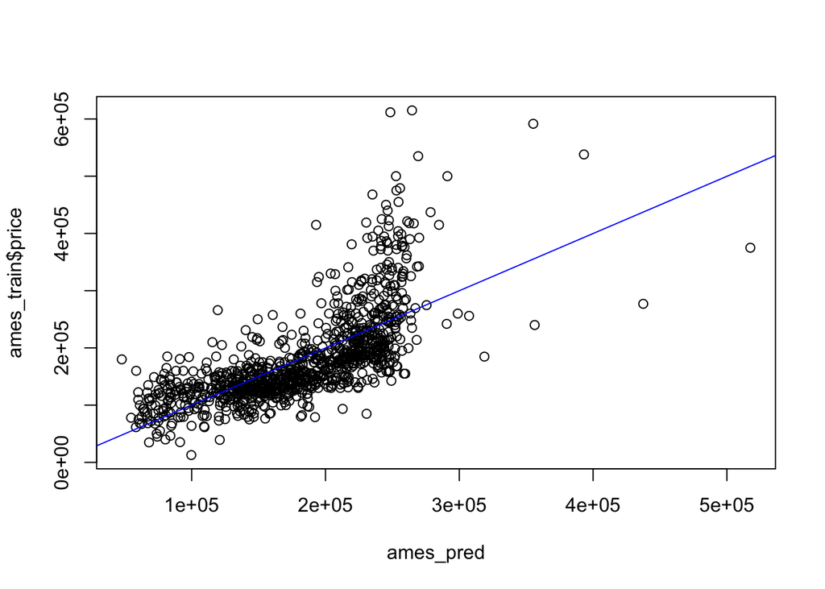

```r
#Set up the dataframe with no log in Lot.Area
ames_no_log <- lm(ames_train$price ~ ames_train$Year.Built + ames_train$Year.Remod.Add +ames_train$Lot.Area + ames_train$Bedroom.AbvGr +ames_train$Land.Slope)

#Set up a scatter plot of predicted log home price vs actual log home price using the model selected
#with the 5 given predictors, including Lot.Area, including a best-fit line
ames_pred <- predict(ames_no_log, ames_train)
plot(ames_pred, ames_train$price)
abline(lm(ames_train$price ~ ames_pred), col = "blue")
```

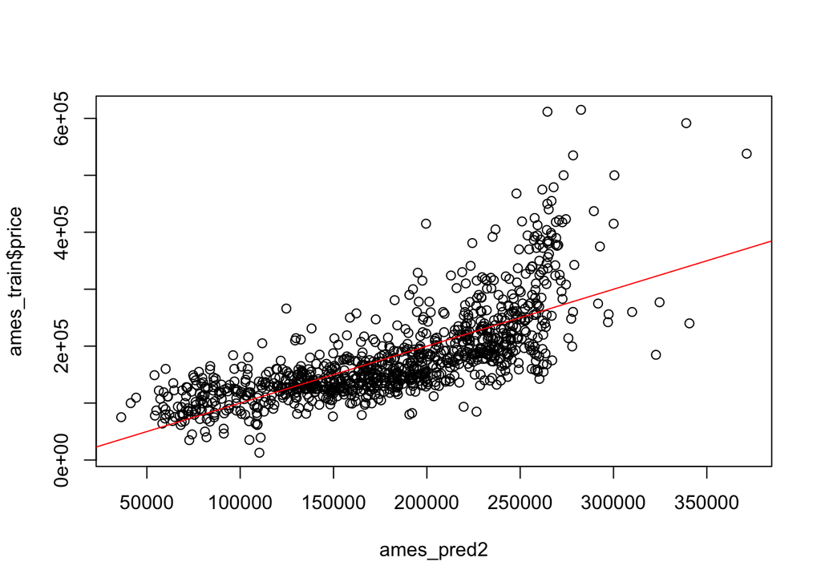

```r
#Set up the dataframe with log in Lot.Area
ames_log <- lm(ames_train$price ~ ames_train$Year.Built + ames_train$Year.Remod.Add + log(ames_train$Lot.Area) + ames_train$Bedroom.AbvGr +ames_train$Land.Slope)

#Set up a scatter plot of predicted log home price vs actual log home price using the model selected
#with the 5 given predictors, including log(Lot.Area), including a best-fit line
ames_pred2 <- predict(ames_log, ames_train)
plot(ames_pred2, ames_train$price)
abline(lm(ames_train$price ~ ames_pred2), col = "red")
```

```r
#Check the first plot's R-Squared
summary(lm(ames_train$price ~ ames_pred))$r.squared
```

```
## [1] 0.4910528
```

```r
#Check the second plot's R-Squared
summary(lm(ames_train$price ~ ames_pred2))$r.squared
```

```
## [1] 0.5299
```

By comparing the two plots, it’s clear that the second plot is with more even distribution than the first plot does. Meanwhile, by checking R-squared value of two plots, the first one is 0.4910528, less than the second one with 0.5299. This indicates the log transformation results in a larger R squared, implying that we should use the model with log transforming Lot. Area.